# Lista 5 - Series

Davi Wentrick Feijó

2024-06-03

Considere a serie do consumo mensal de energia eletrica (ConsumoEnergiaEAgua_New.xlsx). Denotando $X_t$ como o valor do consumo registrado no mes $t$ e $D_t$ como o número de dias de leitura, faca o que se pede a seguir.

```r
# Leitura dos dados
df <- read_excel("ConsumoEnergiaEAgua.xlsx") %>%
  dplyr::select(-c(2,5:11))

# Renomear colunas
colnames(df) <- c('Ano', 'Energia', 'Dias', 'NA')
df <- df[, c('Ano', 'Energia', 'Dias')]  # Selecionar apenas as colunas de interesse
```

#### 1. Calcule o consumo médio diário $Y_t=\frac{x_t}{D_t}$ e explique o porquê dessa transformacao.

```r
# Converter a coluna 'Ano' para o tipo Date
df$Ano <- as.Date(df$Ano, format='%Y-%m-%d')

# Calcular o Consumo Médio Diário
df$Consumo_Medio_Diario <- df$Energia / df$Dias

# Remover linhas com valores NA na coluna 'Consumo_Medio_Diario'
df <- df[!is.na(df$Consumo_Medio_Diario), ]
```

| Ano | Energia | Dias | Consumo_Medio_Diario |
| --- | --- | --- | --- |
| 1997-06-01 | 42 | 42 | 1.000000 |
| 1997-07-01 | 31 | 30 | 1.033333 |
| 1997-08-01 | 73 | 33 | 2.212121 |
| 1997-09-01 | 165 | 29 | 5.689655 |
| 1997-10-01 | 180 | 30 | 6.000000 |
| 1997-11-01 | 199 | 33 | 6.030303 |
| 1997-12-01 | 180 | 29 | 6.206897 |
| 1998-01-01 | 180 | 29 | 6.206897 |
| 1998-02-01 | 155 | 33 | 4.696970 |
| 1998-03-01 | 180 | 29 | 6.206897 |

[output cut: 311 more lines]

A transformação de $Y_t=\frac{x_t}{D_t}$ normaliza o consumo de energia conforme a variação no número de dias de cada mês. Isso permite comparações justas entre meses, eliminando o efeito de diferentes durações mensais. Dividindo o consumo total de energia pelo número de dias do mês, obtém-se uma média diária que reflete melhor o padrão de consumo. Assim, é possível identificar tendências de consumo mais claramente. Dessa forma, a transformação facilita uma análise mais precisa e comparativa entre diferentes períodos.

#### 2. Apresente o gráfico da evolucao temporal de $\left\{Y_t\right\}$, e apresente sua descricao, contemplado elementos como o tamanho da serie e periodicidade dos dados.

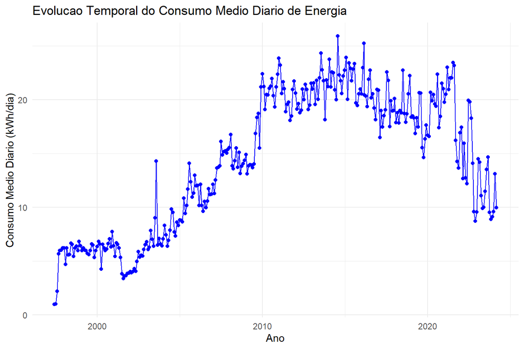